# Ausfallanalyse — Kohnen head03 & head04 (Winter 2026)

Warum beide Iridium-Heads verstummt sind: Telemetrie, Netzstatus, Wetter

Author

Thom Laepple

Published

September 24, 2026

Beide Kohnen-Heads sind im antarktischen Winter 2026 verstummt — **head03 (231709) am 22.07., head04 (231710) am 13.08.** Dieses Dokument sammelt die Diagnostik und rechnet bei jedem Render neu: Telemetrie bis zur letzten Message, Netz-/Vertragsstatus (Cloudloop-API), Wetter am Standort (ERA5T).

**Befund vorab:** Alle bordseitigen Indikatoren (Takt, Batterie, Boxtemperatur, Latenz-Jitter) sind bis zur jeweils letzten Message makellos — zwei An/Aus-Ausfälle ohne Vorboten. Beide fallen exakt auf die zwei stärksten Sturmereignisse des **gesamten Jahres 2026** (ERA5T-Böen: 22.07. Rang 2 mit 23 m/s, 14.08. Rang 1 mit 26 m/s). Plausibelste Ursache: **Sturm-/Driftschaden am Oberflächenteil** (Antenne, Mast, Kabel); die Elektronik liegt ~8–10 m tief und war thermisch stabil.

```r
library(readr); library(dplyr); library(tidyr); library(ggplot2)
library(lubridate); library(patchwork)

HEADS <- tibble(
  head  = c("head03 (231709)", "head04 (231710)"),
  file  = c("./data/decoded_head03_231709_combined.csv",
            "./data/decoded_head04_231710_combined.csv"),
  col   = c("#2166ac", "#b2182b"),
  nominal_h = c(12, 24))

dat <- lapply(seq_len(nrow(HEADS)), function(i)
  read_csv(HEADS$file[i], show_col_types = FALSE) |>
    mutate(time_utc = as_datetime(time_utc), head = HEADS$head[i]) |>
    arrange(time_utc))
names(dat) <- HEADS$head
cols <- setNames(HEADS$col, HEADS$head)
ends <- tibble(head = HEADS$head,
               last = as_datetime(sapply(dat, function(d) max(d$time_utc))))
```

## Status

```r
now_utc <- with_tz(Sys.time(), "UTC")
knitr::kable(
  ends |> mutate(
    `letzte Message (UTC)` = format(last, "%Y-%m-%d %H:%M"),
    `still seit (Tage)` = sprintf("%.1f", as.numeric(difftime(now_utc, last, units = "days"))),
    last = NULL),
  caption = sprintf("Render-Stand %s UTC.", format(now_utc, "%d.%m.%Y %H:%M")))
```

Render-Stand 24.09.2026 12:28 UTC.

| head | letzte Message (UTC) | still seit (Tage) |
| --- | --- | --- |
| head03 (231709) | 2026-07-22 09:03 | 64.1 |
| head04 (231710) | 2026-08-13 17:38 | 41.8 |

## Telemetrie bis zur letzten Message

### Elektronik-Temperatur (Box, ~8–10 m tief)

Jahresgang auf ~1.2 K gedämpft und phaseninvertiert (Minimum Januar/Februar) — die Boxen sitzen tief im Firn. Beide liefen im Januar bei **kälteren** Boxtemperaturen als am Sendeende: Kälte an Modem/Batterie scheidet als Ursache aus.

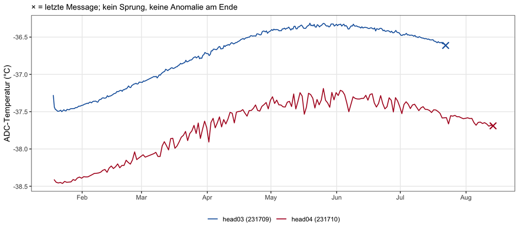

```r
adc <- bind_rows(lapply(dat, function(d) select(d, time_utc, head, val = adc_temp_C)))
ggplot(adc, aes(time_utc, val, colour = head)) +
  geom_line(linewidth = 0.6) +
  geom_point(data = adc |> group_by(head) |> slice_max(time_utc, n = 1),
             size = 3, shape = 4, stroke = 1.2, show.legend = FALSE) +
  scale_colour_manual(NULL, values = cols) +
  scale_x_datetime(NULL, date_breaks = "1 month", date_labels = "%b") +
  labs(y = "ADC-Temperatur (°C)",
       subtitle = "× = letzte Message; kein Sprung, keine Anomalie am Ende") +
  theme_bw(11) + theme(legend.position = "bottom", panel.grid.minor = element_blank())
```

### Batteriespannung

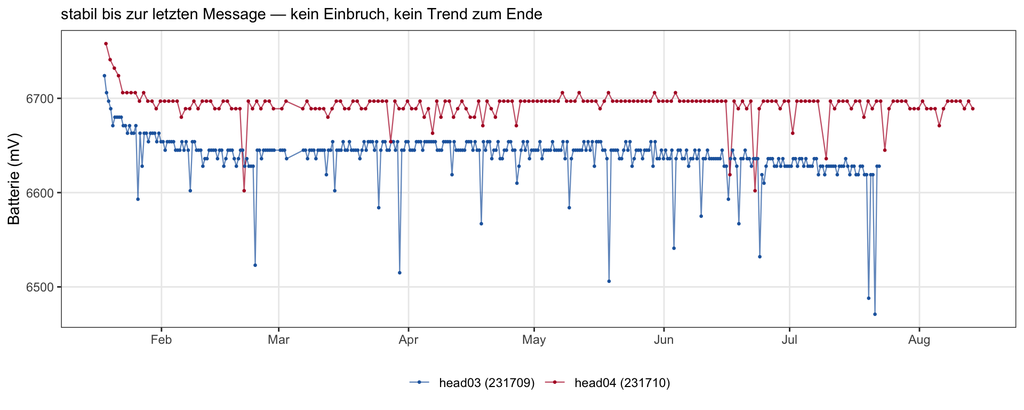

```r
bat <- bind_rows(lapply(dat, function(d) select(d, time_utc, head, val = battery_mv)))
ggplot(bat, aes(time_utc, val, colour = head)) +
  geom_line(linewidth = 0.4, alpha = 0.7) + geom_point(size = 0.5) +
  scale_colour_manual(NULL, values = cols) +
  scale_x_datetime(NULL, date_breaks = "1 month", date_labels = "%b") +
  labs(y = "Batterie (mV)",
       subtitle = "stabil bis zur letzten Message — kein Einbruch, kein Trend zum Ende") +
  theme_bw(11) + theme(legend.position = "bottom", panel.grid.minor = element_blank())
```